# GUV_model_figure

James Foster

2026-05-08

# Details

**DESCRIPTION**

Load and plot circular GLMs to describe all four stimulus conditions.

**INPUTS**

`GUV_functions.R`

**OUTPUTS**

Plotted estimates.

**REFERENCES**

**Experimental approach**

Edrich W, Neumeyer C & von Helversen, O. (1979) “Anti-sun orientation” of bees with regard to a field of ultraviolet light. *J. Comp. Physiol.* 134, 151–157.

Rossel, S. & Wehner, R. (1984). Celestial orientation in bees: the use of spectral cues. *J. Comp. Physiol. A* 155, 605–613.

**modelling methods**

Sayin S, Couzin-Fuchs E, Petelski I, Günzel Y, Salahshour M, Lee CY, Graving JM, Li L, Deussen O, Sword GA, et al. (2025) The behavioral mechanisms governing collective motion in swarming locusts. *Science* 387(6737):995–791

Capretto, T., Piho, C., Kumar, R., Westfall, J., Yarkoni, T., & Martin, O. (2022) `Bambi`: A simple interface for fitting Bayesian linear models in Python. *Journal of Statistical Software* 103(15), 1-29. doi:10.18637/jss.v103.i15

# To Do

- Load Bambi model
- Plot predictions
- Plot contrasts

# Set up workspace

To extract these models, we need to load the appropriate functions. Make sure that the `circular`, `reticulate`, `posterior` and `bayesplot`, are installed, and (on Windows) that you have installed the latest version of [Rtools](https://cran.r-project.org/bin/windows/Rtools/). Here we first set up a `reticulate` Python environment with the appropriate versions of each package, then reload reticulate to ensure that those packages are available.

```r
source('GUV_functions.R')
require(reticulate)
```

```r
reticulate::py_install(c(
  "numpy==1.26.4",
  "pandas==2.1.4",
  "scipy==1.11.4",
  "arviz==0.17.1",
  "packaging"
), method = "pip")
```

```
## Using virtual environment "C:/Users/James Foster/Documents/.virtualenvs/r-reticulate" ...
```

```
## + "C:/Users/James Foster/Documents/.virtualenvs/r-reticulate/Scripts/python.exe" -m pip install --upgrade --no-user "numpy==1.26.4" "pandas==2.1.4" "scipy==1.11.4" "arviz==0.17.1" packaging
```

```r
require(reticulate)
require(posterior)
```

```r
require(bayesplot)
options(posterior.num_args = list(sigfig = 3))#for ease of reading
```

Set up some colours for plotting.

```r
col_kappa = '#1E78B5'#colour for kappa parameter
col_rho = '#F08024' #colour for mean vector length
col_sd = '#E74A29' #colour for SD and mean angle
col_sd2 = '#E57461' #colour for other SD heuristics
col_pdf = adjustcolor(col = '#21A885', # colour for probability density
                      alpha.f = 0.7)
col_obs = '#3E1F51' #colour for control observations
col_treat = '#006400' # colour for treatment observations
```

# Prepare data

Then load the data that will be used. This is our dance data, reorganised by `GUV_organisedata.R` as `colour_dance_reorg.csv`.

```r
#Dance angle data
cd = read.table(file = '1Data/colour_dance_reorg.csv',
                header = T,
                sep  = ',')
head(cd)
```

```
##   measured_angle run       date bearing       angle               ID brightn
## 1            270   1 2016.05.31      90  1.57079633 2016.05.31.14.24       l
## 2              5   2 2016.05.31     355 -0.08726646 2016.05.31.14.24       l
## 3             20   3 2016.05.31     340 -0.34906585 2016.05.31.14.24       l
## 4            320   4 2016.05.31      40  0.69813170 2016.05.31.14.24       l
## 5             20   5 2016.05.31     340 -0.34906585 2016.05.31.14.24       l
## 6             35   6 2016.05.31     325 -0.61086524 2016.05.31.14.24       l
##   colour            cet_time   sun_az   sun_el sun_el_rad sun_az_rad
## 1      u 2016-05-31 14:24:00 208.3263 58.81733   1.026556  -2.647205
## 2      u 2016-05-31 14:24:00 208.3263 58.81733   1.026556  -2.647205
## 3      u 2016-05-31 14:24:00 208.3263 58.81733   1.026556  -2.647205
## 4      u 2016-05-31 14:24:00 208.3263 58.81733   1.026556  -2.647205
## 5      u 2016-05-31 14:24:00 208.3263 58.81733   1.026556  -2.647205
## 6      u 2016-05-31 14:24:00 208.3263 58.81733   1.026556  -2.647205
```

## Format data

Ensure that each variable has the correct data format for subsequent analysis.

```r
cd = within(cd,
            {
              ID = as.factor(ID) # beedance identifier as a factor
              date = as.factor(date) # date as a factor
              signed_angle = Mod360.180(bearing)  # bearing between -180 and 180
              angle = circular(rad(signed_angle),# bearing between -pi and pi
                               rotation = 'clock') # circular format suppresses later warnings
            }
)
u_id = with(cd, unique(ID)) # unique beedances
length(u_id)#169 beedances
```

```
## [1] 169
```

```r
cd = within(cd,
            {
              BR = brightn
              CL = colour
              DT = date
              RN = run
            }
)
```

## Identify dances for both conditions

```r
uvc = sapply(u_id,
              FUN = function(id, dt)
                {
                with(subset(dt,
                            ID %in% id &
                              colour %in% 'u'),
                     {
                       length(unique(brightn))
                       }
                     )
              },
              dt = cd)

#There should be two brightness levels for UV
uv_ids = u_id[uvc == 2]
length(uv_ids)#most individuals
```

```
## [1] 154
```

```r
#extract just those individuals

#find data for full condition individuals
cd_uv = subset(cd, ID %in% uv_ids)
```

# Load Bambi model and extract draws for each parameter

```r
#Import arviz for model handling
az = reticulate::import("arviz")
# Load the NetCDF file
idata = az$from_netcdf("2Results/GUV_unwrap_model.nc")
# Convert to data frame
posterior_df = reticulate::py_to_r(x =                                         idata$posterior$to_dataframe()
                                   )
```

Set up metadata about draws for sorting.

```r
# Initial Metadata -----------------------------------------------------

n_ind = 169
n_chains = 4
obs_per_chain = nrow(posterior_df) /
                    (n_ind * n_chains) # Calculated automatically

# Individual changes every row (1,2...169, 1,2...169)
posterior_df = within(posterior_df,
                      {
                Individual_ID = rep(x = 1:n_ind,
                         times = n_chains * obs_per_chain)

    # Iteration changes every 169 rows (1,1... (169 times), 2,2... (169 times))
                .iteration    = rep(x = rep(x = 1:obs_per_chain,
                                 each = n_ind),
                         times = n_chains)

# Chain changes every (169 * obs_per_chain) rows
                .chain        = rep(x = 1:n_chains,
                                    each = obs_per_chain * n_ind)
                      }
)
# Define Parameter Groupings
global_params = c(
  "Intercept", "B", "C", "B:C",
  "kappa_Intercept", "kappa_B", "kappa_C", "kappa_B:C",
  "1|Individual_kappa", "B|Individual_kappa", "C|Individual_kappa", "B:C|Individual_kappa",
  "kappa_1|Individual_sigma", "kappa_B|Individual_sigma",
  "kappa_C|Individual_sigma", "kappa_B:C|Individual_sigma",
  "kappa_1|Individual_offset", "kappa_B|Individual_offset",
  "kappa_C|Individual_offset", "kappa_B:C|Individual_offset"
)

ind_params = c(
  "1|Individual", "B|Individual", "C|Individual", "B:C|Individual",
  "kappa_1|Individual", "kappa_B|Individual", "kappa_C|Individual", "kappa_B:C|Individual"
)
```

```r
# Reshape posterior draws -------------------------------------------------

# Reshape to Wide Format
list_of_inds = split(x = posterior_df,
                     f = posterior_df$Individual_ID)

# Start wide df with metadata and population-level parameters
existing_globals = intersect(x = global_params,
                             y = colnames(posterior_df))
# take the first individual's data as a template for the wide data frame
draws_wide  =  list_of_inds[[1]][, c(".chain", ".iteration", existing_globals)]

# Pivot individual-level parameters into columns
for(param in ind_params)
  {
  if(param %in% colnames(posterior_df))
    {
    clean_base = gsub("\\|", "_", param)
    for(i in 1:n_ind) {
      draws_wide[[paste0(clean_base, "_Ind_", i)]] = list_of_inds[[i]][[param]]
    }
  }
}

# Export to draws dataframe
draws_final = posterior::as_draws_df(draws_wide)
```

# Inspect model estimates

This model identifies both a population level bias (near 0°) and individual biases with stable parameter estimates on the ‘unwrapped’ (circular modulo) scale.

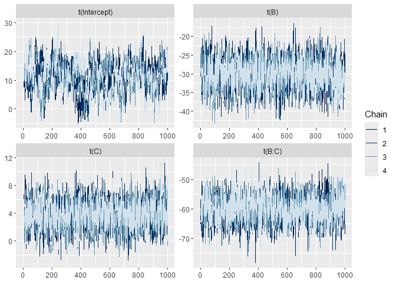

```r
mcmc_trace(draws_final,
           pars = c('Intercept', 'B', 'C', 'B:C'),
           transformations = unwrap_circular_deg)
```

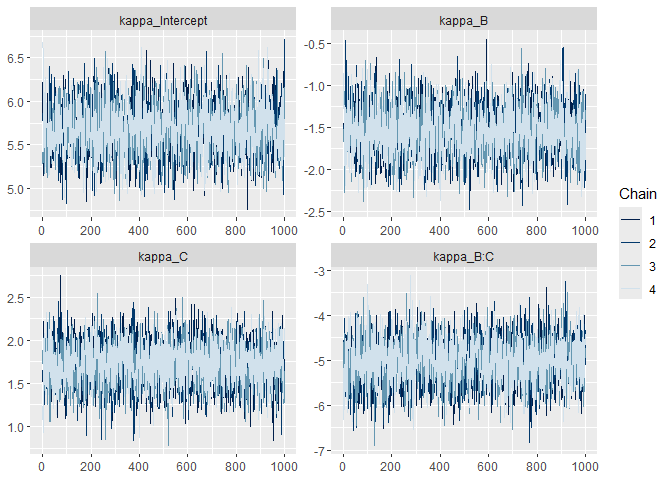

```r
mcmc_trace(draws_final,
           pars = paste0("kappa_",
                         c('Intercept', 'B', 'C', 'B:C')) )
```

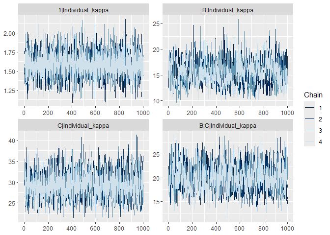

```r
mcmc_trace(draws_final,
           pars = paste0( c('1', 'B', 'C', 'B:C'),
                          '|Individual_kappa') )
```

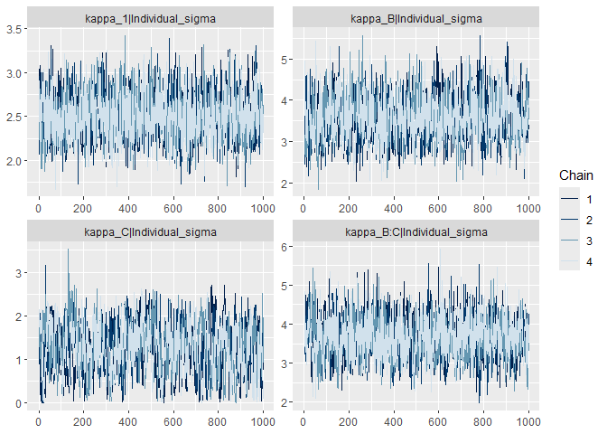

```r
mcmc_trace(draws_final,
           pars = paste0('kappa_',
                         c('1', 'B', 'C', 'B:C'),
                         '|Individual_sigma') )
```

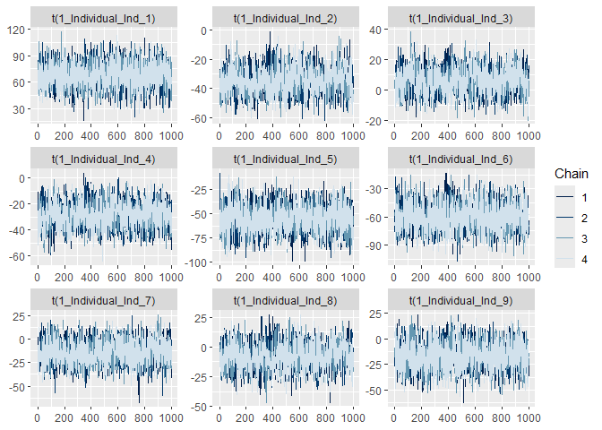

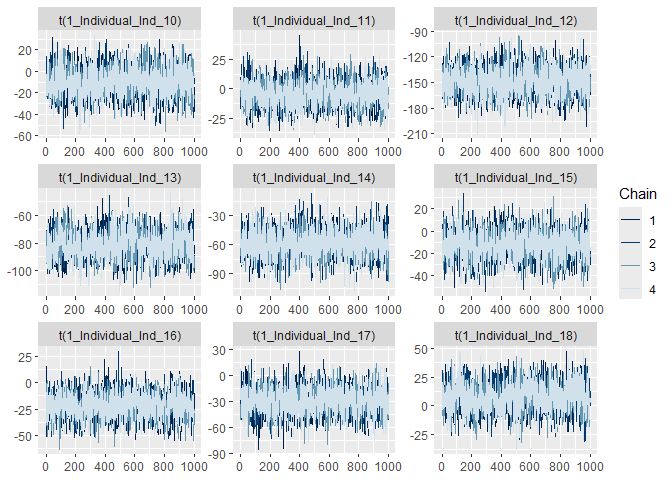

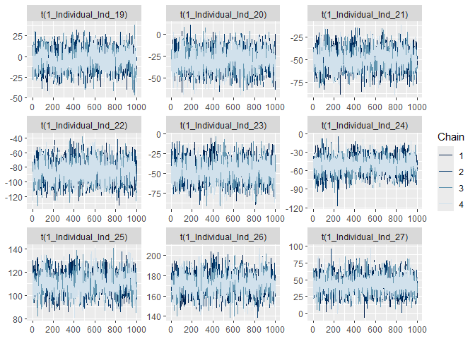

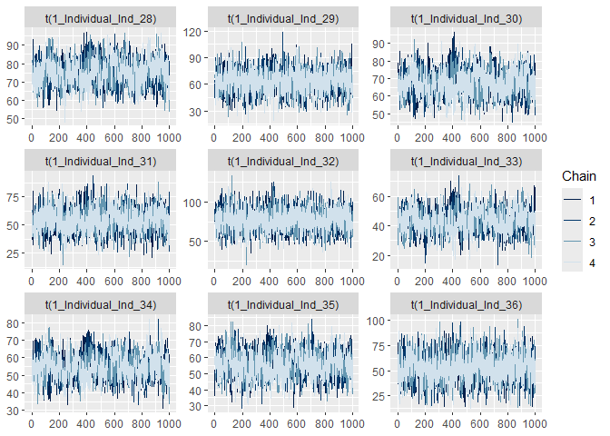

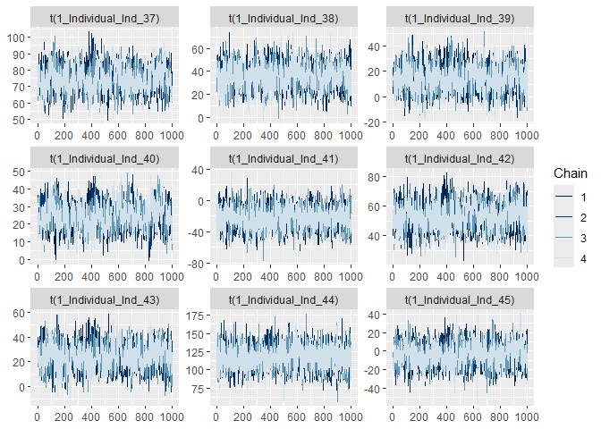

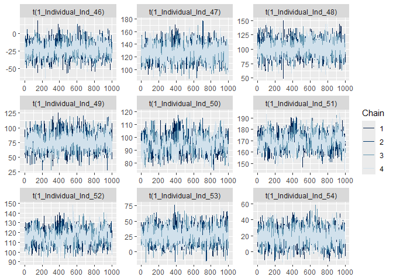

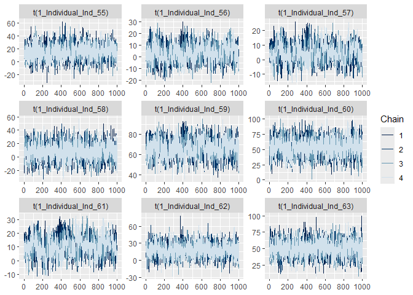

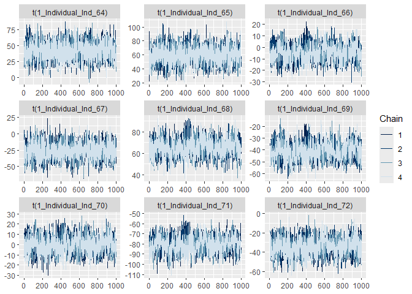

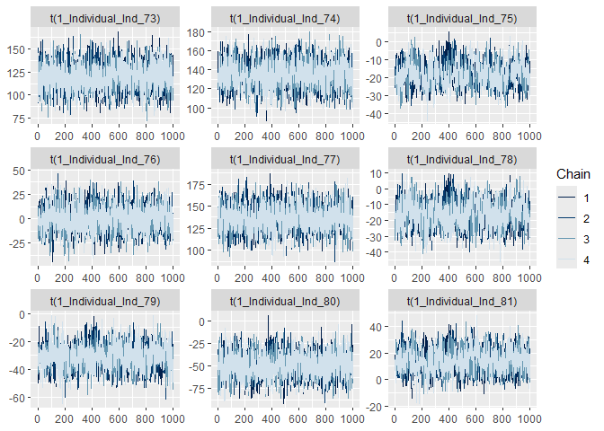

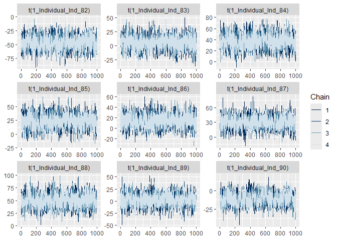

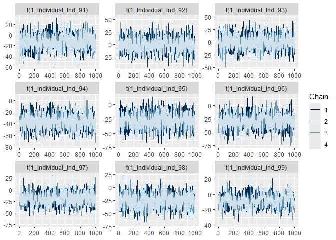

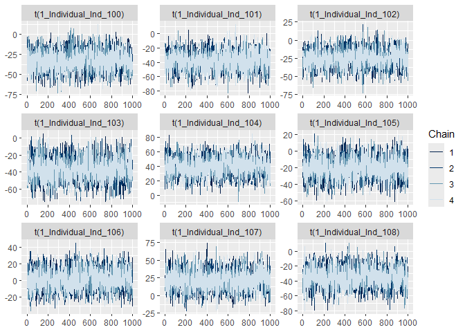

[7 more figures not shown]

```r
plt_panels = 9
#individual but they overlap when unwrapped
for(id in 0:(ceiling(length(u_id)/plt_panels)-1))
{
  # Calculate the specific range of indices for this page
  start_idx = (id * plt_panels) + 1
  end_idx   = min((id + 1) * plt_panels, length(u_id))
plt = mcmc_trace(draws_final,
           pars = paste0("1_Individual_Ind_",
                         start_idx:end_idx),
           facet_args = list(ncol = 3,
                             nrow = 3),
           transformations = unwrap_circular_deg
           )
print(plt)
}
```

```r
sm_fixed = summarise_draws(draws_final[,c(1:16)],
                           .num_args = list(digits = 3))
# print(sm_all$fixed[c(1,5:6+20),], digits = 3)
sm_fixed[, c('variable', 'median', 'q5', 'q95', 'rhat')]
```

```
## # A tibble: 16 × 5
##    variable                   median     q5    q95  rhat
##    <chr>                       <dbl>  <dbl>  <dbl> <dbl>
##  1 Intercept                   0.200  0.041  0.331 1.003
##  2 B                          -0.526 -0.642 -0.410 1.000
##  3 C                           0.065  0.006  0.124 1.000
##  4 B:C                        -1.048 -1.177 -0.918 1.002
##  5 kappa_Intercept             5.677  5.222  6.157 1.000
##  6 kappa_B                    -1.532 -2.005 -1.058 1.000
##  7 kappa_C                     1.720  1.308  2.127 1.000
##  8 kappa_B:C                  -5.034 -5.861 -4.254 1.000
##  9 1|Individual_kappa          1.582  1.330  1.849 1.000
## 10 B|Individual_kappa         15.434 12.053 19.117 1.003
## 11 C|Individual_kappa         29.250 24.907 34.490 1.000
## 12 B:C|Individual_kappa       19.770 16.013 24.519 1.000
## 13 kappa_1|Individual_sigma    2.494  2.086  2.940 1.000
## 14 kappa_B|Individual_sigma    3.552  2.760  4.455 1.000
## 15 kappa_C|Individual_sigma    1.294  0.283  2.125 1.000
## 16 kappa_B:C|Individual_sigma  3.625  2.836  4.507 1.000
```

```r
# print(sm_all$random, digits = 3)
# print(sm_all$spec_pars, digits = 3)
#
# #mu0 and mui look bad, but good after unwrapping
# UnwrapRhats(draws_final,
#             variable = '^b_mu0')
# summary(UnwrapRhats(draws_final,
#             variable = '^b_mui') )
```

```r
azsum_fixed = az$summary(idata,
           var_names=c("Intercept", #slightly right shifted, should converge to around 0.26
               "B",
                "C",
                "B:C",
                "kappa_Intercept",
               "kappa_B",
                "kappa_C",
                "kappa_B:C"
                ),
    circ_var_names=c("Intercept",
                    "B",
                    "C",
                    "B:C"
                    )
)
print(azsum_fixed[, c(1, 3, 4, 7, 9)], digits = 3)
```

```
##                   mean hdi_3% hdi_97% ess_bulk r_hat
## Intercept        0.196  0.026   0.359      229  1.01
## B               -0.526 -0.660  -0.392     2299  1.00
## C                0.066 -0.003   0.130     2417  1.00
## B:C             -1.048 -1.183  -0.887     1144  1.01
## kappa_Intercept  5.683  5.161   6.231     3082  1.00
## kappa_B         -1.532 -2.082  -1.002     2990  1.00
## kappa_C          1.721  1.243   2.168     3064  1.00
## kappa_B:C       -5.043 -6.021  -4.194     2463  1.00
```

```r
azsum_ranef = az$summary(idata,
           var_names=c( "1|Individual_kappa",
        "B|Individual_kappa",
        "C|Individual_kappa",
        "B:C|Individual_kappa",
        "kappa_1|Individual_sigma",
        "kappa_B|Individual_sigma",
        "kappa_C|Individual_sigma",
        "kappa_B:C|Individual_sigma"
                )
)
print(azsum_ranef[, c(1, 3, 4, 7, 9)], digits = 3)
```

```
##                             mean hdi_3% hdi_97% ess_bulk r_hat
## 1|Individual_kappa          1.59  1.289    1.88     9442  1.00
## B|Individual_kappa         15.50 11.376   19.34      183  1.01
## C|Individual_kappa         29.38 24.054   34.91     2852  1.00
## B:C|Individual_kappa       19.93 15.348   24.95      984  1.00
## kappa_1|Individual_sigma    2.50  2.029    3.00     1693  1.00
## kappa_B|Individual_sigma    3.58  2.622    4.55     1172  1.00
## kappa_C|Individual_sigma    1.26  0.185    2.23      482  1.01
## kappa_B:C|Individual_sigma  3.64  2.659    4.57     1115  1.01
```

## Extract predictions

```r
#A function to find the circular median in (-pi, pi)
MedCDraws = function(x,
                     templ = 'none', #assumes radians
                     medn = 1) #take the 1st median
{
  median.circular( circular(x = mod_circular(x),
                            template = templ)
                                           )[medn]
}
QCDraws = function(x,
                   probs = c(0.025, 0.5, 0.975),
                     templ = 'none',
                     medn = 1)
{
  quantile.circular( circular(x = mod_circular(x),
                            template = templ),
                     probs = probs
                                           )
}
```

```r
# Setup containers for summary statistics
u_id_num <- 1:n_ind
mu_id_gh <- kappa_id_gh <- numeric(length(u_id_num))
mu_id_uh <- kappa_id_uh <- numeric(length(u_id_num))
mu_id_gl <- kappa_id_gl <- numeric(length(u_id_num))
mu_id_ul <- kappa_id_ul <- numeric(length(u_id_num))

# Create one Master List for all raw draws
# Structure: individual_draws[[i]]$mu$gh
individual_draws <- vector("list", length(u_id_num))

for(i in seq_along(u_id_num)) {

  calc <- within(draws_final, {
    # Dynamic fetch
    m_i   <- get(paste0("1_Individual_Ind_", i))
    m_bi  <- get(paste0("B_Individual_Ind_", i))
    m_ci  <- get(paste0("C_Individual_Ind_", i))
    m_bci <- get(paste0("B:C_Individual_Ind_", i))

    k_i   <- get(paste0("kappa_1_Individual_Ind_", i))
    k_bi  <- get(paste0("kappa_B_Individual_Ind_", i))
    k_ci  <- get(paste0("kappa_C_Individual_Ind_", i))
    k_bci <- get(paste0("kappa_B:C_Individual_Ind_", i))

    # Calculate Raw Vectors
    gh_mu_vec <- Intercept + m_i
    gh_ka_vec <- kappa_Intercept + k_i

    uh_mu_vec <- Intercept + m_i + C + m_ci
    uh_ka_vec <- kappa_Intercept + k_i + kappa_C + k_ci

    gl_mu_vec <- Intercept + m_i + B + m_bi
    gl_ka_vec <- kappa_Intercept + k_i + kappa_B + k_bi

    ul_mu_vec <- Intercept + m_i + B + C + `B:C` + m_bi + m_ci + m_bci
    ul_ka_vec <- kappa_Intercept + k_i + kappa_B + kappa_C + `kappa_B:C` + k_bi + k_ci + k_bci
  })

  # Save to the Nested List
  individual_draws[[i]] <- list(
    mu    = list(gh = calc$gh_mu_vec, uh = calc$uh_mu_vec, gl = calc$gl_mu_vec, ul = calc$ul_mu_vec),
    kappa = list(gh = calc$gh_ka_vec, uh = calc$uh_ka_vec, gl = calc$gl_ka_vec, ul = calc$ul_ka_vec)
  )

  # Store summary stats for quick table access
  mu_id_gh[i] <- MedCDraws(calc$gh_mu_vec)
  kappa_id_gh[i] <- median(calc$gh_ka_vec)

  mu_id_uh[i] <- MedCDraws(calc$uh_mu_vec)
  kappa_id_uh[i] <- median(calc$uh_ka_vec)

  mu_id_gl[i] <- MedCDraws(calc$gl_mu_vec)
  kappa_id_gl[i] <- median(calc$gl_ka_vec)

  mu_id_ul[i] <- MedCDraws(calc$ul_mu_vec)
  kappa_id_ul[i] <- median(calc$ul_ka_vec)
}
```

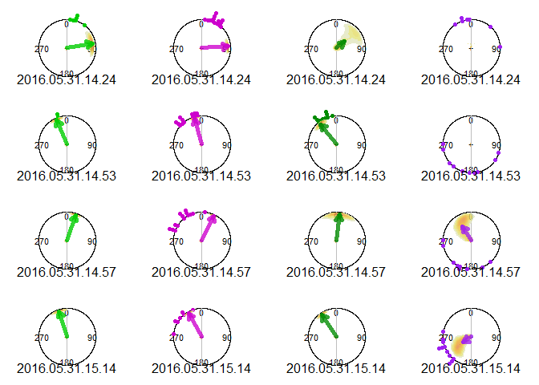

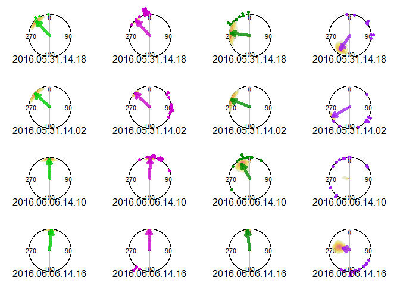

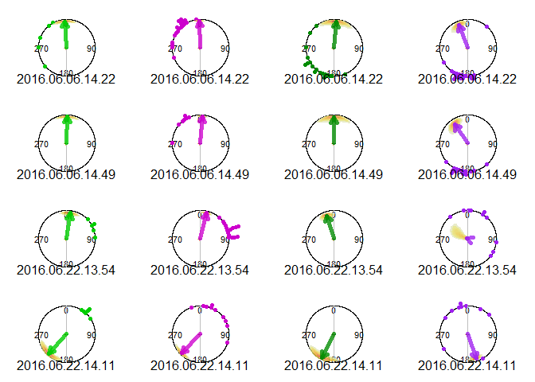

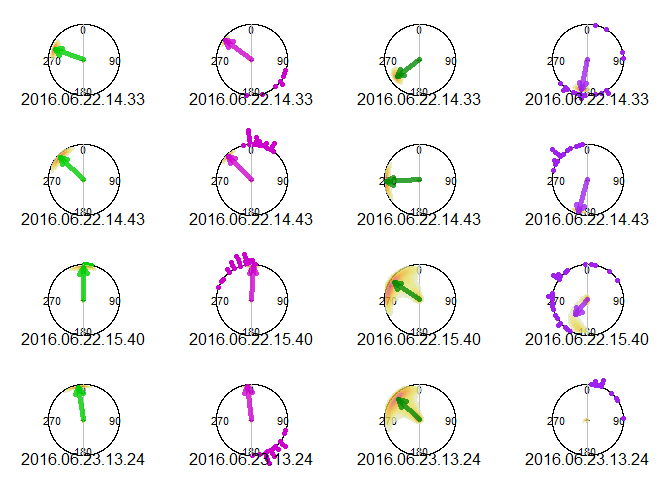

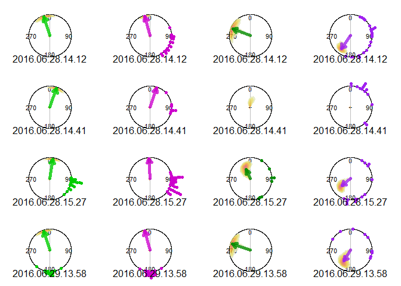

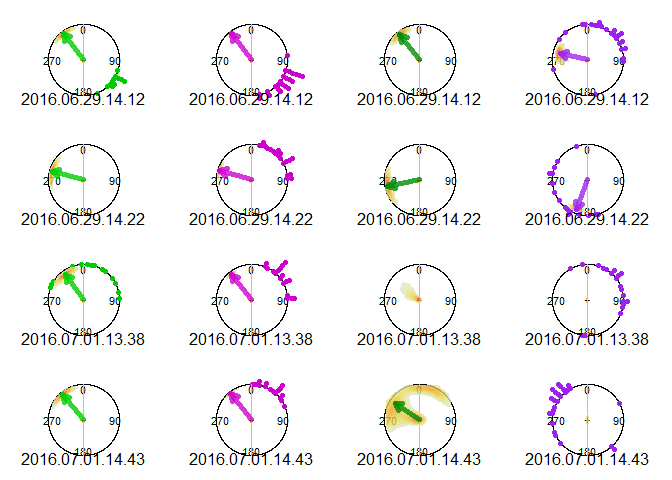

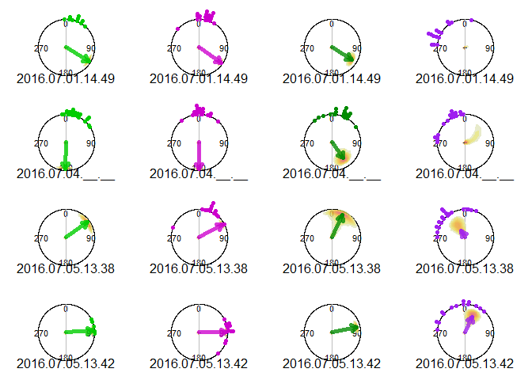

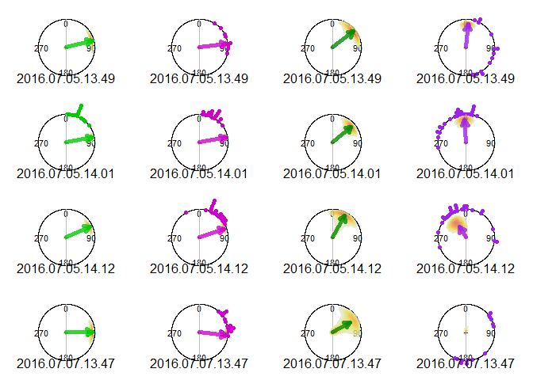

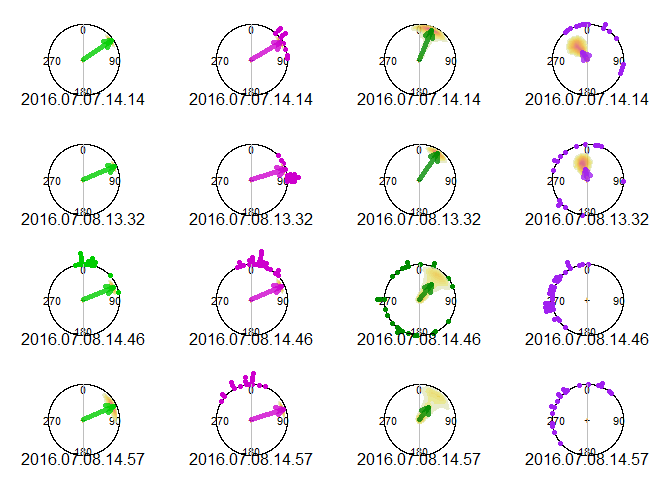

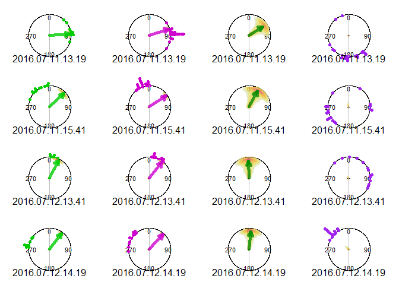

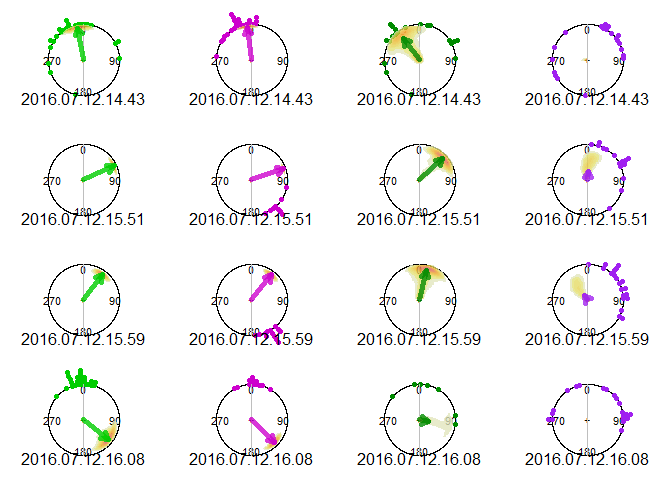

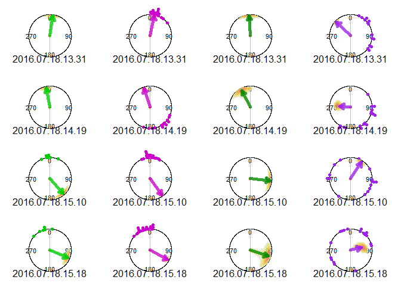

[31 more figures not shown]

```r
par(pty = 's')
par(mar = c(0,0,0,0),
    mfrow = c(4,4) )
for(i in 1:length(u_id) )
# for(i in 20+1:50 )
{

  # Construct the exact column names
  mu_i   = paste0("1_Individual_Ind_", i)
  mu_bi  = paste0("B_Individual_Ind_", i)
  mu_ci  = paste0("C_Individual_Ind_", i)
  mu_bci = paste0("B:C_Individual_Ind_", i)

  ka_i   = paste0("kappa_1_Individual_Ind_", i)
  ka_bi  = paste0("kappa_B_Individual_Ind_", i)
  ka_ci  = paste0("kappa_C_Individual_Ind_", i)
  ka_bci = paste0("kappa_B:C_Individual_Ind_", i)

  #green high
  with(subset(cd,
              ID %in% u_id[i] &
                CL %in% 'g' & BR %in% 'h'),
  {
    PCfun(angles = bearing,
         col = 'green3',
         plot_rho = FALSE,
         title = u_id[i])
    }
  )
  Draws2Cont(individual_draws[[i]],
           x_string = paste0('sin(mu$gh) * A1(softplus(kappa$gh))'),
           y_string = paste0('cos(mu$gh) * A1(softplus(kappa$gh))')
  )

  arrows.circular(
    x = circular(mu_id_gh[i],
                 units = 'radians',
                 rotation = 'clock',
                 zero = pi/2),
    y = A1(softplus(kappa_id_gh[i])), # Ensure softplus is applied here
    lwd = 5,
    length = 0.1/1.25,
    col = adjustcolor('green3', alpha.f = 0.8)
  )

  #UV high
  with(subset(cd,
              ID %in% u_id[i] &
                CL %in% 'u' & BR %in% 'h'),
  {
    PCfun(angles = bearing,
         col = 'magenta3',
         plot_rho = FALSE,
         title = u_id[i])
    }
  )
   Draws2Cont(individual_draws[[i]],
           x_string = paste0('sin(mu$uh) * A1(softplus(kappa$uh))'),
           y_string = paste0('cos(mu$uh) * A1(softplus(kappa$uh))')
  )
  arrows.circular(x = circular(x = mu_id_uh[i],
                               units = 'radians',
                              rotation = 'clock',
                              zero = pi/2),
                 y = A1(kappa_id_uh[i]),
                 lwd = 5,
                 length = 0.1/1.25,
                 col = adjustcolor('magenta3', alpha.f = 200/255))

  #green low
  with(subset(cd,
              ID %in% u_id[i] &
                CL %in% 'g' & BR %in% 'l'),
  {
    PCfun(angles = bearing,
         col = 'green4',
         plot_rho = FALSE,
         title = u_id[i])
    }
  )
   Draws2Cont(individual_draws[[i]],
           x_string = paste0('sin(mu$gl) * A1(softplus(kappa$gl))'),
           y_string = paste0('cos(mu$gl) * A1(softplus(kappa$gl))')
  )
  arrows.circular(x = circular(x = mu_id_gl[i],
                               units = 'radians',
                              rotation = 'clock',
                              zero = pi/2),
                 y = A1(kappa_id_gl[i]),
                 lwd = 5,
                 length = 0.1/1.25,
                 col = adjustcolor('green4', alpha.f = 200/255))
  #
  #UV low
  with(subset(cd,
              ID %in% u_id[i] &
                CL %in% 'u' & BR %in% 'l'),
  {
    PCfun(angles = bearing,
         col = 'purple',
         plot_rho = FALSE,
         title = u_id[i])
    }
  )
  Draws2Cont(individual_draws[[i]],
           x_string = paste0('sin(mu$ul) * A1(softplus(kappa$ul))'),
           y_string = paste0('cos(mu$ul) * A1(softplus(kappa$ul))')
  )
  arrows.circular(x = circular(x = mu_id_ul[i],
                               units = 'radians',
                              rotation = 'clock',
                              zero = pi/2),
                 y = A1(kappa_id_ul[i]),
                 lwd = 5,
                 length = 0.1/1.25,
                 col = adjustcolor('purple', alpha.f = 200/255))
}
```

## Plot population level predictions

```r
#calculate mean vectors
mean_vectors = aggregate(angle~ID*brightn*colour,#+sun_az+sun_el_rad, # N.B. Including sun azimuth drops some cases without a time stamp
                         data = cd,
                         FUN = rho.circular
)
#correct names
mean_vectors = within(mean_vectors,
                      {mean_vector = angle; rm(angle)} # angle now indicates a mean vector, not an angle
)
#add kappa
mle_estimates = aggregate(angle~ID*brightn*colour,#+sun_az+sun_el,
                          data = cd,
                          FUN = MLE_est
)
#Rayleigh tests
rayleigh_tests = aggregate(angle~ID*brightn*colour,#+sun_az+sun_el,
                          data = cd,
                          FUN = Rayleigh_p
                          )
#add to the summary table and
#calculate inverse softplus kappa
mean_vectors = within(mean_vectors,
                      {
                        mu = deg(mle_estimates$angle[,'mu'])
                        kappa = mle_estimates$angle[,'kappa']
                        iskappa  = inv_softplus(kappa)
                      }
)

luc = sapply(u_id,
              FUN = IndCond,
              dt = cd)

#Most individuals that made it to bright green
full_ids = u_id[luc == 4]

#find pair conditions
#green
grc = sapply(u_id,
              FUN = function(id, dt)
                {
                with(subset(dt,
                            ID %in% id &
                              colour %in% 'g'),
                     {
                       length(unique(brightn))
                       }
                     )
              },
              dt = cd)
#bright
brc = sapply(u_id,
              FUN = function(id, dt)
                {
                with(subset(dt,
                            ID %in% id &
                              brightn %in% 'h'),
                     {
                       length(unique(colour))
                       }
                     )
              },
              dt = cd)
#UV
uvc = sapply(u_id,
              FUN = function(id, dt)
                {
                with(subset(dt,
                            ID %in% id &
                              colour %in% 'u'),
                     {
                       length(unique(brightn))
                       }
                     )
              },
              dt = cd)
#dim
dic = sapply(u_id,
              FUN = function(id, dt)
                {
                with(subset(dt,
                            ID %in% id &
                              brightn %in% 'l'),
                     {
                       length(unique(colour))
                       }
                     )
              },
              dt = cd)

#There should be two brightness levels for green
gr_ids = u_id[grc == 2]
#There should be two colour levels for bright
br_ids = u_id[brc == 2]
#There should be two brightness levels for UV
uv_ids = u_id[uvc == 2]
#There should be two colour levels for dim
di_ids = u_id[dic == 2]

#condition specific
gh_ids = with(subset(cd,
                     subset = CL %in% 'g' &
                       BR %in% 'h'),
              unique(ID)
              )
uh_ids = with(subset(cd,
                     subset = CL %in% 'u' &
                       BR %in% 'h'),
              unique(ID)
              )
gl_ids = with(subset(cd,
                     subset = CL %in% 'g' &
                       BR %in% 'l'),
              unique(ID)
              )
ul_ids = with(subset(cd,
                     subset = CL %in% 'u' &
                       BR %in% 'l'),
              unique(ID)
              )


mu_diff_gl = sapply(X = gr_ids,
                    FUN = MuDiff,
                    dt = mean_vectors,
                    cl = 'g',
                    br = 'l')
mu_diff_uh = sapply(X = br_ids,
                    FUN = MuDiff,
                    dt = mean_vectors,
                    cl = 'u',
                    br = 'h')
mu_diff_ul = sapply(X = uv_ids,
                    FUN = MuDiff,
                    dt = mean_vectors,
                    cl = 'u',
                    br = 'l')
mu_diff_ugl = sapply(X = di_ids,
                    FUN = MuDiff,
                    dt = mean_vectors,
                     cl = 'u',
                    br = 'l',
                    ref_cl = 'g',
                    ref_br = 'h')
```

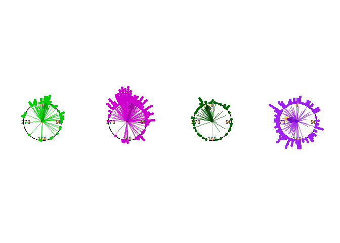

```r
par(pty = 's')
# Population mean for green bright (Baseline: Intercept)
par(mfrow = c(1,4), mar = c(0,0,0,0))

with(subset(mean_vectors, colour %in% 'g' & brightn %in% 'h'), {
  PCfun(angles = mu, col = 'green3', shrink = 2, plot_rho = FALSE)
})

for(i in which(u_id %in% gh_ids)) {
  arrows.circular(x = circular(x = mu_id_gh[i], units = 'radians', rotation = 'clock', zero = pi/2),
                  y = A1(kappa_id_gh[i]), lwd = 0.25, length = 0,
                  col = adjustcolor('green3', alpha.f = 200/255))
}

Draws2Cont(draws = draws_final,
           x_string = 'sin(Intercept) * A1(softplus(kappa_Intercept))',
           y_string = 'cos(Intercept) * A1(softplus(kappa_Intercept))')

with(draws_final,
     arrows.circular(x = circular(x = MedCDraws(Intercept),
                                  units = 'radians',
                                  rotation = 'clock', zero = pi/2),
                     y = A1(median(softplus(kappa_Intercept))),
                     lwd = 5, length = 0.1/1.25,
                     col = adjustcolor('green3', alpha.f = 200/255, offset = c(rep(-0.2,3),0) )
     )
)


# pop mean for UV bright (Intercept + C)
with(subset(mean_vectors, colour %in% 'u' & brightn %in% 'h'), {
  PCfun(angles = mu, col = 'magenta3', shrink = 2, plot_rho = FALSE)
})

for(i in which(u_id %in% uh_ids) )
{

  arrows.circular(x = circular(x = mu_id_uh[i],
                               units = 'radians',
                              rotation = 'clock',
                              zero = pi/2),
                 y = A1(kappa_id_uh[i]),
                 lwd = 0.25,
                 length = 0,
                 col = adjustcolor('magenta3', alpha.f = 200/255))
}

Draws2Cont(draws = draws_final,
           x_string = 'sin(Intercept + C) * A1(softplus(kappa_Intercept + kappa_C))',
           y_string = 'cos(Intercept + C) * A1(softplus(kappa_Intercept + kappa_C))')

with(draws_final,
     arrows.circular(x = circular(x = MedCDraws(Intercept + C), units = 'radians', rotation = 'clock', zero = pi/2),
                     y = A1(median(softplus(kappa_Intercept + kappa_C))),
                     lwd = 5, length = 0.1/1.25, col = adjustcolor('magenta3', alpha.f = 200/255, offset = c(rep(-0.2,3),0)))
)

# pop mean for green dim (Intercept + B)
with(subset(mean_vectors, colour %in% 'g' & brightn %in% 'l'), {
  PCfun(angles = mu, col = 'darkgreen', shrink = 2, plot_rho = FALSE)
})


for(i in which(u_id %in% gl_ids) )
{

  arrows.circular(x = circular(x = mu_id_gl[i],
                               units = 'radians',
                              rotation = 'clock',
                              zero = pi/2),
                 y = A1(kappa_id_gl[i]),
                 lwd = 0.25,
                 length = 0,
                 col = adjustcolor('darkgreen', alpha.f = 200/255 ))
}
Draws2Cont(draws = draws_final,
           x_string = 'sin(Intercept + B) * A1(softplus(kappa_Intercept + kappa_B))',
           y_string = 'cos(Intercept + B) * A1(softplus(kappa_Intercept + kappa_B))')

with(draws_final,
     arrows.circular(x = circular(x = MedCDraws(Intercept + B), units = 'radians', rotation = 'clock', zero = pi/2),
                     y = A1(median(softplus(kappa_Intercept + kappa_B))),
                     lwd = 5, length = 0.1/1.25, col = adjustcolor('darkgreen', alpha.f = 200/255, offset = c(rep(-0.2,3),0)))
)

# pop mean for UV dim (Intercept + B + C + BC)
with(subset(mean_vectors, colour %in% 'u' & brightn %in% 'l'), {
  PCfun(angles = mu, col = 'purple', shrink = 2, plot_rho = FALSE)
})


for(i in which(u_id %in% ul_ids) )
{

  arrows.circular(x = circular(x = mu_id_ul[i],
                               units = 'radians',
                              rotation = 'clock',
                              zero = pi/2),
                 y = A1(kappa_id_ul[i]),
                 lwd = 0.25,
                 length = 0,
                 col = adjustcolor('purple', alpha.f = 200/255)
  )
}
Draws2Cont(draws = draws_final,
           x_string = 'sin(Intercept + B + C + `B:C`) * A1(softplus(kappa_Intercept + kappa_B + kappa_C + `kappa_B:C`))',
           y_string = 'cos(Intercept + B + C + `B:C`) * A1(softplus(kappa_Intercept + kappa_B + kappa_C + `kappa_B:C`))')

with(draws_final,
     arrows.circular(x = circular(x = MedCDraws(Intercept + B + C + `B:C`), units = 'radians', rotation = 'clock', zero = pi/2),
                     y = A1(median(softplus(kappa_Intercept + kappa_B + kappa_C + `kappa_B:C`))),
                     lwd = 5, length = 0.1/1.25, col = adjustcolor('purple', alpha.f = 200/255, offset = c(rep(-0.2,3),0)))
)
```

```r
par(pty = 's')
# Population mean for green bright (Baseline: Intercept)
par(mfrow = c(1,4), mar = c(0,0,0,0))

# --- Effect of UV ---
PCfun(angles = unlist(mu_diff_uh),
      col = 'gray40',
      shrink = 2,
      plot_rho = FALSE)

for(i in which(u_id %in% uv_ids)) {
  # UV high
  arrows.circular(x = circular(x = mu_id_uh[i] - mu_id_gh[i],
                               units = 'radians',
                               rotation = 'clock',
                               zero = pi/2),
                  y = A1(kappa_id_uh[i]),
                  lwd = 0.5,
                  length = 0,
                  col = adjustcolor('magenta3', alpha.f = 200/255))
}

Draws2Cont(draws = draws_final,
           x_string = 'sin(C) * A1(softplus(kappa_C))',
           y_string = 'cos(C) * A1(softplus(kappa_C))')

with(draws_final,
     arrows.circular(x = circular(x = MedCDraws(C),
                                  units = 'radians',
                                  rotation = 'clock',
                                  zero = pi/2),
     y = A1(median(softplus(kappa_C))),
     lwd = 5,
     length = 0.1/1.25,
     col = adjustcolor('gray40', alpha.f = 200/255))
)

with(draws_final,
     {
       round(deg(
         quantile(mod_circular(C), probs = c(0.5, 0.025, 0.975))
       ))
     }
)
```

```
##   50%  2.5% 97.5%
##     4     0     8
```

```r
# --- Effect of dim green ---
PCfun(angles = unlist(mu_diff_gl),
      col = 'darkgreen',
      shrink = 2,
      plot_rho = FALSE)

# green low
for(i in which(u_id %in% gr_ids)) {
  arrows.circular(x = circular(x = mu_id_gl[i] - mu_id_gh[i],
                               units = 'radians',
                               rotation = 'clock',
                               zero = pi/2),
                  y = A1(kappa_id_gl[i]),
                  lwd = 0.25,
                  length = 0,
                  col = adjustcolor('green4', alpha.f = 200/255))
}
Draws2Cont(draws = draws_final,
           x_string = 'sin(B) * A1(softplus(kappa_B))',
           y_string = 'cos(B) * A1(softplus(kappa_B))')

with(draws_final,
     {
       round(deg(
         quantile(mod_circular(B), probs = c(0.5, 0.025, 0.975))
       ))
     }
)
```

```
##   50%  2.5% 97.5%
##   -30   -38   -22
```

```r
with(draws_final,
     arrows.circular(x = circular(x = MedCDraws(B),
                                  units = 'radians',
                                  rotation = 'clock',
                                  zero = pi/2),
     y = A1(median(softplus(kappa_B))),
     lwd = 5,
     length = 0.1/1.25,
     col = adjustcolor('darkgreen', alpha.f = 200/255))
)

# --- Effect of dim UV ---
PCfun(angles = unlist(mu_diff_ul),
      col = 'purple',
      shrink = 2,
      plot_rho = FALSE)

# UV low
for(i in which(u_id %in% uv_ids)) {
  arrows.circular(x = circular(x = mu_id_ul[i] - mu_id_uh[i],
                               units = 'radians',
                               rotation = 'clock',
                               zero = pi/2),
                  y = A1(kappa_id_ul[i]),
                  lwd = 0.25,
                  length = 0,
                  col = adjustcolor('purple', alpha.f = 200/255))
}
# The difference between UV bright and UV dim is brightness and the interaction
Draws2Cont(draws = draws_final,
           x_string = 'sin(B + `B:C`) * A1(softplus(kappa_B + `kappa_B:C`))',
           y_string = 'cos(B + `B:C`) * A1(softplus(kappa_B + `kappa_B:C`))')

with(draws_final,
     {
       round(deg(
         quantile(mod_circular(B + `B:C`), probs = c(0.5, 0.025, 0.975))
       ))
     }
)
```

```
##   50%  2.5% 97.5%
##   -90   -97   -84
```

```r
with(draws_final,
     arrows.circular(x = circular(x = MedCDraws(B + `B:C`),
                                  units = 'radians',
                                  rotation = 'clock',
                                  zero = pi/2),
     y = A1(median(softplus(kappa_B + `kappa_B:C`))),
     lwd = 5,
     length = 0.1/1.25,
     col = adjustcolor('purple', alpha.f = 200/255))
)
# --- Effect of dim UV relative to dim green ---
PCfun(angles = unlist(mu_diff_ugl),
      col = 'gray25',
      shrink = 2,
      plot_rho = FALSE)

# UV low
for(i in which(u_id %in% di_ids)) {
  arrows.circular(x = circular(x = mu_id_ul[i] - mu_id_gl[i],
                               units = 'radians',
                               rotation = 'clock',
                               zero = pi/2),
                  y = A1(kappa_id_ul[i]),
                  lwd = 0.25,
                  length = 0,
                  col = adjustcolor('gray25', alpha.f = 200/255))
}
# The difference between green dim and UV dim is colour and the interaction
Draws2Cont(draws = draws_final,
           x_string = 'sin(C + `B:C`) * A1(softplus(kappa_C + `kappa_B:C`))',
           y_string = 'cos(C + `B:C`) * A1(softplus(kappa_C + `kappa_B:C`))')

with(draws_final,
     {
       round(deg(
         quantile(mod_circular(C + `B:C`), probs = c(0.5, 0.025, 0.975))
       ))
     }
)
```

```
##   50%  2.5% 97.5%
##   -56   -65   -47
```

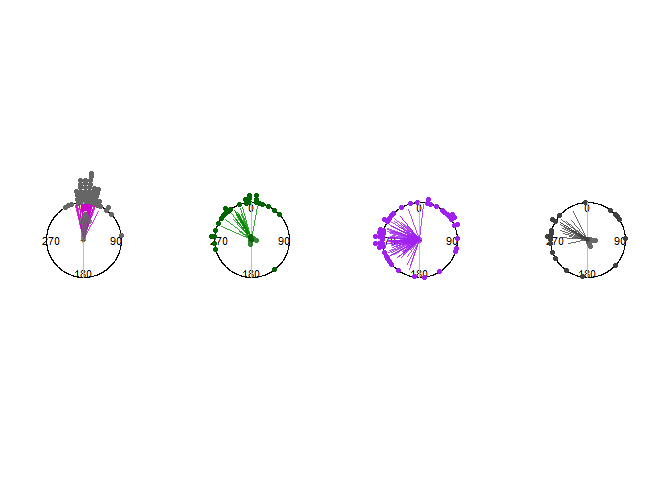

```r
with(draws_final,
     arrows.circular(x = circular(x = MedCDraws(C + `B:C`),
                                  units = 'radians',
                                  rotation = 'clock',
                                  zero = pi/2),
     y = A1(median(softplus(kappa_C + `kappa_B:C`))),
     lwd = 5,
     length = 0.1/1.25,
     col = adjustcolor('gray25', alpha.f = 200/255))
)
```

```r
#plot kappa
par(mfrow = c(1,4))

with(draws_final,
     VertHist(data = softplus(kappa_Intercept),
              main = '\ngreen bright',
              ylab = 'kappa',
              ylim = c(0, 15),
              col = adjustcolor('green3', alpha.f = 100/255),
              axes = FALSE,
              cex.axis = 0.7))
axis(1)
axis(2, at = 0:5*5)

with(draws_final,
     VertHist(data = softplus(kappa_Intercept + kappa_C),
              main = '\nUV bright',
              ylab = 'kappa',
              ylim = c(0, 15),
              col = adjustcolor('magenta3', alpha.f = 100/255),
              axes = FALSE,
              cex.axis = 0.7))
axis(1)
axis(2, at = 0:5*5)

with(draws_final,
     {
       round(
     quantile(softplus(kappa_Intercept + kappa_C) -
                softplus(kappa_Intercept),
              probs = c(0.5, 0.025, 0.975)),
     digits = 2
       )
     }
)
```

```
##   50%  2.5% 97.5%
##  1.72  1.23  2.19
```

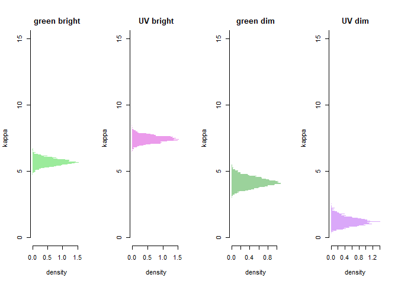

```r
with(draws_final,
     VertHist(data = softplus(kappa_Intercept + kappa_B),
              main = '\ngreen dim',
              ylab = 'kappa',
              ylim = c(0, 15),
              col = adjustcolor('green4', alpha.f = 100/255),
              axes = FALSE,
              cex.axis = 0.7))
axis(1)
axis(2, at = 0:5*5)

with(draws_final,
     VertHist(data = softplus(kappa_Intercept + kappa_B  + kappa_C +  + `kappa_B:C`),
              main = '\nUV dim',
              ylab = 'kappa',
              ylim = c(0, 15),
              col = adjustcolor('purple', alpha.f = 100/255),
              axes = FALSE,
              cex.axis = 0.7))
axis(1)
axis(2, at = 0:5*5)
```

```r
with(draws_final,
     {
       round(
     quantile(softplus(kappa_Intercept + kappa_B) -
                softplus(kappa_Intercept),
              probs = c(0.5, 0.025, 0.975)),
     digits = 2
       )
     }
)
```

```
##   50%  2.5% 97.5%
## -1.52 -2.07 -0.96
```